# Scene Data Exploration

28 June, 2017

The SCENE dataset consists of 16 tables, but we’ll focus this course on the five most relevant tables. These tables describe the SCENE customers and their transactions.

This document looks at each column of each table. Please sit back, relax, and enjoy the show!

Load the required libraries.

Set folder path

```r
in_path = '/global/project/queens-mma/scene-csv/sample03/clean/'
```

# Table: scene_mbr_dim

```r
scene_mbr_dim <- read_csv(paste(in_path, 'scene_mbr_dim.csv', sep=""))
```

Here are the details of the table:

```r
dim(scene_mbr_dim)
```

```
## [1] 338135     29
```

```r
colnames(scene_mbr_dim)
```

```
##  [1] "scene_mbr_key"          "scene_mbr_seq_num"
##  [3] "eff_from_tmstamp"       "eff_to_tmstamp"
##  [5] "brth_dt"                "psnl_post_cd"
##  [7] "psnl_prov_state_cd"     "psnl_city"
##  [9] "suspended_f"            "gndr_tp_ref_key"
## [11] "gndr_desc"              "prefrd_loctn_ref_key"
## [13] "prefrd_loctn_desc"      "email_prefnc_ref_key"
## [15] "email_prefnc_desc"      "ed_lvl_tp_ref_key"
## [17] "ed_lvl_desc"            "prefrd_show_tm_ref_key"
## [19] "prefrd_show_tm_desc"    "num_of_hh_pple_ref_key"
## [21] "num_of_hh_pple_desc"    "movie_gng_frq_ref_key"
## [23] "movie_gng_frq_ref_desc" "mrtl_stat_ref_key"
## [25] "mrtl_stat_desc"         "lang_ref_key"
## [27] "lang_desc"              "scene_mbr_acct_key"
## [29] "scene_acty_stat"
```

```r
str(scene_mbr_dim)
```

```
## Classes 'tbl_df', 'tbl' and 'data.frame':    338135 obs. of  29 variables:
##  $ scene_mbr_key         : int  5345055 5608646 8220183 3235025 3069398 4309287 5564154 3406464 4629884 3793788 ...
##  $ scene_mbr_seq_num     : int  1 1 2 13 4 2 1 2 1 3 ...
##  $ eff_from_tmstamp      : POSIXct, format: "2011-04-26 23:19:58" "2011-08-11 23:23:02" ...
##  $ eff_to_tmstamp        : POSIXct, format: "2012-02-16 17:02:05" "2012-02-16 17:51:50" ...
##  $ brth_dt               : int  1987 1996 1996 1986 1947 1991 1978 1951 1996 1984 ...
##  $ psnl_post_cd          : chr  "V4V" "N2N" "V3W" "N1E" ...
##  $ psnl_prov_state_cd    : chr  "BC" "ON" "BC" "ON" ...
##  $ psnl_city             : chr  "lake country" "kitchener" "surrey" "guelph" ...
##  $ suspended_f           : int  0 0 0 0 0 0 0 0 0 0 ...
##  $ gndr_tp_ref_key       : int  39 39 40 39 39 40 39 39 39 39 ...
##  $ gndr_desc             : chr  "Male" "Male" "Female" "Male" ...
##  $ prefrd_loctn_ref_key  : int  -1 -1 -1 291 199 298 -1 256 -1 167 ...
##  $ prefrd_loctn_desc     : chr  "Unknown" "Unknown" "Unknown" "Galaxy Cinemas Waterloo" ...
##  $ email_prefnc_ref_key  : int  98 98 98 98 98 98 98 98 98 98 ...
##  $ email_prefnc_desc     : chr  "HTML" "HTML" "HTML" "HTML" ...
##  $ ed_lvl_tp_ref_key     : int  -1 -1 -1 148 150 145 -1 -1 -1 150 ...
##  $ ed_lvl_desc           : chr  "Unknown" "Unknown" "Unknown" "Some University" ...
##  $ prefrd_show_tm_ref_key: int  -1 -1 -1 74 66 72 -1 73 -1 75 ...
##  $ prefrd_show_tm_desc   : chr  NA NA NA "8:00pm" ...
##  $ num_of_hh_pple_ref_key: int  -1 -1 -1 54 55 54 -1 54 -1 54 ...
##  $ num_of_hh_pple_desc   : chr  "Unkno" "Unkno" "Unkno" "1" ...
##  $ movie_gng_frq_ref_key : int  -1 -1 -1 65 63 65 -1 64 -1 62 ...
##  $ movie_gng_frq_ref_desc: chr  NA NA NA "20+" ...
##  $ mrtl_stat_ref_key     : int  -1 -1 -1 42 41 42 -1 -1 42 41 ...
##  $ mrtl_stat_desc        : chr  "Unknown" "Unknown" "Unknown" "Single" ...
##  $ lang_ref_key          : int  37 37 37 37 37 37 37 37 37 37 ...
##  $ lang_desc             : chr  "English" "English" "English" "English" ...
##  $ scene_mbr_acct_key    : int  3100397 3365564 5972659 494224 948210 2146632 3317059 841695 2384963 1785742 ...
##  $ scene_acty_stat       : chr  "NULL" "NULL" "0" "0" ...
##  - attr(*, "spec")=List of 2
##   ..$ cols   :List of 29
##   .. ..$ scene_mbr_key         : list()
##   .. .. ..- attr(*, "class")= chr  "collector_integer" "collector"
##   .. ..$ scene_mbr_seq_num     : list()
##   .. .. ..- attr(*, "class")= chr  "collector_integer" "collector"
##   .. ..$ eff_from_tmstamp      :List of 1
##   .. .. ..$ format: chr ""
##   .. .. ..- attr(*, "class")= chr  "collector_datetime" "collector"
##   .. ..$ eff_to_tmstamp        :List of 1
```

[output cut: 40 more lines]

```
##   .. ..$ mrtl_stat_ref_key     : list()
##   .. .. ..- attr(*, "class")= chr  "collector_integer" "collector"
##   .. ..$ mrtl_stat_desc        : list()
##   .. .. ..- attr(*, "class")= chr  "collector_character" "collector"
##   .. ..$ lang_ref_key          : list()
##   .. .. ..- attr(*, "class")= chr  "collector_integer" "collector"
##   .. ..$ lang_desc             : list()
##   .. .. ..- attr(*, "class")= chr  "collector_character" "collector"
##   .. ..$ scene_mbr_acct_key    : list()
##   .. .. ..- attr(*, "class")= chr  "collector_integer" "collector"
##   .. ..$ scene_acty_stat       : list()
##   .. .. ..- attr(*, "class")= chr  "collector_character" "collector"
##   ..$ default: list()
##   .. ..- attr(*, "class")= chr  "collector_guess" "collector"
##   ..- attr(*, "class")= chr "col_spec"
```

```r
summary(scene_mbr_dim)
```

```
##  scene_mbr_key      scene_mbr_seq_num eff_from_tmstamp
##  Min.   : 2245019   Min.   :  1.000   Min.   :2010-03-04 12:49:02
##  1st Qu.: 3382108   1st Qu.:  1.000   1st Qu.:2010-09-15 23:16:03
##  Median : 4535386   Median :  1.000   Median :2012-02-16 17:16:17
##  Mean   : 5031594   Mean   :  1.812   Mean   :2012-02-12 04:09:36
##  3rd Qu.: 6337072   3rd Qu.:  2.000   3rd Qu.:2013-03-11 22:51:13
##  Max.   :11241506   Max.   :202.000   Max.   :2016-09-08 01:31:39
##                                       NA's   :1
##  eff_to_tmstamp                   brth_dt     psnl_post_cd
##  Min.   :2010-03-08 10:49:29   Min.   :1901   Length:338135
##  1st Qu.:2012-02-16 17:25:27   1st Qu.:1968   Class :character
##  Median :2012-09-17 22:30:22   Median :1981   Mode  :character
##  Mean   :2013-05-28 20:30:19   Mean   :1977
##  3rd Qu.:2014-10-03 00:41:03   3rd Qu.:1989
##  Max.   :2016-09-09 00:10:24   Max.   :2011
##  NA's   :1                     NA's   :730
##  psnl_prov_state_cd  psnl_city          suspended_f      gndr_tp_ref_key
##  Length:338135      Length:338135      Min.   :0.00000   Min.   :   -1.0
##  Class :character   Class :character   1st Qu.:0.00000   1st Qu.:   39.0
##  Mode  :character   Mode  :character   Median :0.00000   Median :   40.0
##                                        Mean   :0.04069   Mean   :   45.1
##                                        3rd Qu.:0.00000   3rd Qu.:   40.0
##                                        Max.   :1.00000   Max.   :12301.0
##                                        NA's   :1         NA's   :1
##   gndr_desc         prefrd_loctn_ref_key prefrd_loctn_desc
##  Length:338135      Min.   :  -1.0       Length:338135
##  Class :character   1st Qu.:  -1.0       Class :character
##  Mode  :character   Median :  -1.0       Mode  :character
##                     Mean   : 123.7
##                     3rd Qu.: 224.0
##                     Max.   :4701.0
##                     NA's   :1
##  email_prefnc_ref_key email_prefnc_desc  ed_lvl_tp_ref_key
##  Min.   :-1.0         Length:338135      Min.   : -1.00
##  1st Qu.:98.0         Class :character   1st Qu.: -1.00
##  Median :98.0         Mode  :character   Median : -1.00
##  Mean   :81.2                            Mean   : 44.18
##  3rd Qu.:98.0                            3rd Qu.:145.00
##  Max.   :99.0                            Max.   :151.00
##  NA's   :1                               NA's   :1
```

[output cut: 17 more lines]

```
##  Length:338135          Min.   :-1.00     Length:338135
##  Class :character       1st Qu.:-1.00     Class :character
##  Mode  :character       Median :41.00     Mode  :character
##                         Mean   :25.78
##                         3rd Qu.:42.00
##                         Max.   :45.00
##                         NA's   :1
##   lang_ref_key    lang_desc         scene_mbr_acct_key scene_acty_stat
##  Min.   :-1.00   Length:338135      Min.   :     -1    Length:338135
##  1st Qu.:37.00   Class :character   1st Qu.:1212280    Class :character
##  Median :37.00   Mode  :character   Median :2290602    Mode  :character
##  Mean   :36.93                      Mean   :2805669
##  3rd Qu.:37.00                      3rd Qu.:4091904
##  Max.   :38.00                      Max.   :8978272
##  NA's   :1                          NA's   :1
```

Here are the first 20 rows of the data:

```r
head(scene_mbr_dim, n=20)
```

```
## # A tibble: 20 x 29
##    scene_mbr_key scene_mbr_seq_num    eff_from_tmstamp      eff_to_tmstamp
##            <int>             <int>              <dttm>              <dttm>
##  1       5345055                 1 2011-04-26 23:19:58 2012-02-16 17:02:05
##  2       5608646                 1 2011-08-11 23:23:02 2012-02-16 17:51:50
##  3       8220183                 2 2014-10-03 00:39:35 2016-08-22 23:35:36
##  4       3235025                13 2016-03-15 23:24:05 2016-03-17 13:51:05
##  5       3069398                 4 2012-02-16 17:11:25 2016-03-24 23:21:57
##  6       4309287                 2 2012-02-16 17:33:31 2012-05-21 22:30:59
##  7       5564154                 1 2011-07-27 23:23:42 2012-02-16 17:26:09
##  8       3406464                 2 2011-02-10 23:26:30 2012-02-16 17:27:34
##  9       4629884                 1 2010-05-12 05:57:32 2012-02-16 17:57:14
## 10       3793788                 3 2011-04-19 20:29:39 2012-02-16 18:01:54
## 11       6306803                 1 2012-05-28 22:37:11 2014-10-03 00:26:23
## 12       5368493                 1 2011-05-07 23:20:17 2012-02-16 17:32:22
## 13       8423682                 2 2015-08-24 23:52:13 2015-10-17 23:17:57
## 14       2715422                 1 2010-03-04 12:55:49 2012-02-16 17:28:06
## 15       2610404                 2 2011-02-10 23:34:49 2012-02-16 17:31:42
## 16       3419418                 2 2011-02-10 23:30:27 2012-02-16 17:35:52
## 17       2694302                 2 2010-06-08 23:14:02 2011-02-10 23:43:17
## 18       6513433                 1 2012-07-25 22:36:53 2016-08-22 23:30:21
## 19       8919434                 1 2014-08-11 22:57:54 2014-10-03 00:43:45
## 20       2940004                 1 2010-03-04 12:57:04 2012-02-16 17:23:48
## # ... with 25 more variables: brth_dt <int>, psnl_post_cd <chr>,
## #   psnl_prov_state_cd <chr>, psnl_city <chr>, suspended_f <int>,
## #   gndr_tp_ref_key <int>, gndr_desc <chr>, prefrd_loctn_ref_key <int>,
## #   prefrd_loctn_desc <chr>, email_prefnc_ref_key <int>,
## #   email_prefnc_desc <chr>, ed_lvl_tp_ref_key <int>, ed_lvl_desc <chr>,
## #   prefrd_show_tm_ref_key <int>, prefrd_show_tm_desc <chr>,
## #   num_of_hh_pple_ref_key <int>, num_of_hh_pple_desc <chr>,
## #   movie_gng_frq_ref_key <int>, movie_gng_frq_ref_desc <chr>,
## #   mrtl_stat_ref_key <int>, mrtl_stat_desc <chr>, lang_ref_key <int>,
## #   lang_desc <chr>, scene_mbr_acct_key <int>, scene_acty_stat <chr>
```

## Member Entry Sequence (scene_mbr_seq_num)

This variable is not properly defined in the metadata. From the dataset, it appears that this number represents a unique entry for each customer and is used for customer record history. Whenever a member is entered in a database, s/he is assigned scene_mbr_seq_num as ‘1’. At the next change, this variable is changed to ‘2’ and so on. Thus, ‘1’ represents the first entry for the customer.

```r
summary(scene_mbr_dim$scene_mbr_seq_num)
```

```
##    Min. 1st Qu.  Median    Mean 3rd Qu.    Max.
##   1.000   1.000   1.000   1.812   2.000 202.000
```

```r
group_by(scene_mbr_dim, scene_mbr_seq_num)%>%
  summarise(count=n(), percentage = n()/nrow(scene_mbr_dim))%>%
  arrange(desc(count))
```

```
## # A tibble: 35 x 3
##    scene_mbr_seq_num  count   percentage
##                <int>  <int>        <dbl>
##  1                 1 170214 0.5033906576
##  2                 2 100174 0.2962544546
##  3                 3  43860 0.1297115058
##  4                 4  15413 0.0455823857
##  5                 5   5214 0.0154198767
##  6                 6   2052 0.0060685821
##  7                 7    716 0.0021174974
##  8                 8    251 0.0007423071
##  9                 9     96 0.0002839103
## 10                10     49 0.0001449125
## # ... with 25 more rows
```

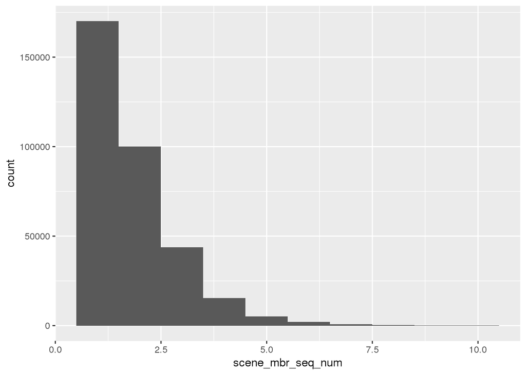

```r
# ploting seq number <= 10 as the data is extremly skewed
scene_mbr_dim %>%
  filter(scene_mbr_seq_num <= 10) %>%
  ggplot(aes(x=scene_mbr_seq_num)) +
  geom_histogram(bins = 10)
```

Because of this definition of sequence number, 50% of the records are ‘1’, while one third is ‘2’. Higher sequence numbers exponentially drop off. Sequence numbers can be used in combination with next parameters to understand the trends in the number of new customers and their renewal timelines.

## Effective Timestamps (eff_from_tmstamp, eff_to_tmstamp)

These timestamps represent the time period for which each sequence number is applicable.

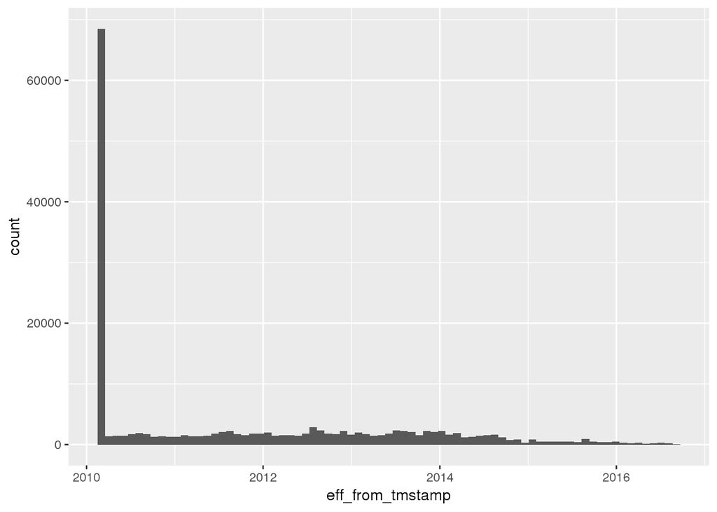

```r
scene_mbr_dim %>%
  filter(scene_mbr_seq_num==1) %>%
  ggplot(aes(x=eff_from_tmstamp)) +
  geom_histogram(bins = 77)
```

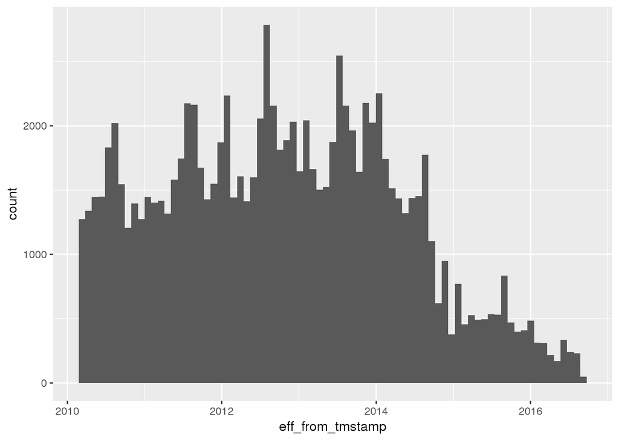

```r
scene_mbr_dim %>%
  filter(scene_mbr_seq_num==1 & eff_from_tmstamp>ymd(20100305)) %>%
  ggplot(aes(x=eff_from_tmstamp)) +
  geom_histogram(bins = 77)
```

Removing these initial entries and plotting again shows that new customers might have declined since 2014. (However, later analysis suggest possibility of database lag. See section on ‘scene_mbr_acct_dim’ for more details.) During the year, there appears to be cyclicality as there seems to be spikes around summer months.

Plotting of data with sequence numbers such as ‘2’ and ‘3’ shows when the entries were updated.

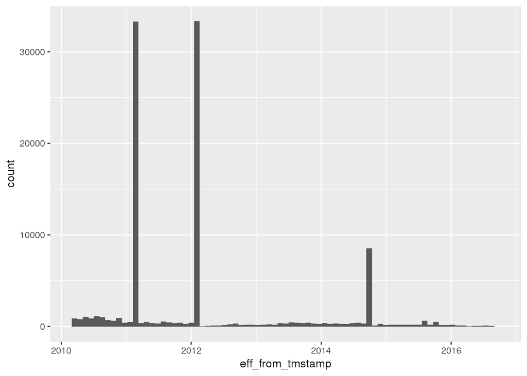

```r
scene_mbr_dim %>%
  filter(scene_mbr_seq_num==2) %>%
  ggplot(aes(x=eff_from_tmstamp))+
  geom_histogram(bins = 77)
```

In plot of sequence number ‘2’ there are two spikes in March, 2011 and March, 2012, suggesting that the records created in March, 2010 might have been updated in bulk after 1 and 2 years respectively. There is also a spike toward the end of 2014, suggesting another bulk data ingestion.

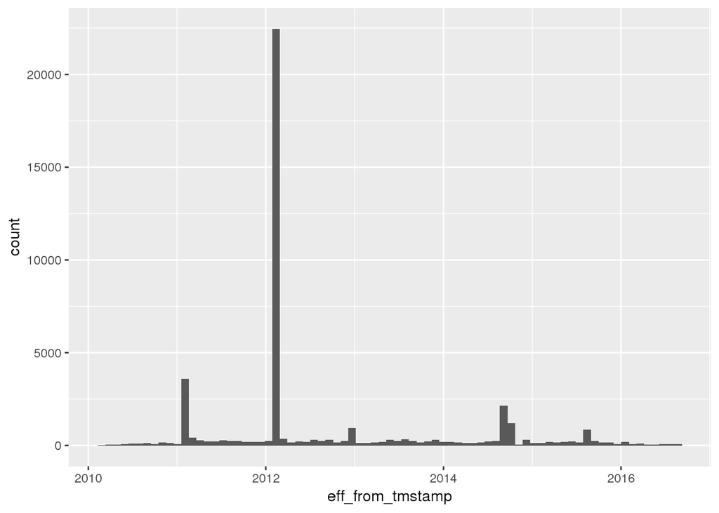

```r
scene_mbr_dim %>%
  filter(scene_mbr_seq_num==3) %>%
  ggplot(aes(x=eff_from_tmstamp)) +
  geom_histogram(bins = 77)
```

For all subsequent sequence numbers, there is spike around March 2012 indicating that there were updates in 2012, but subsequently there have been only small number of renewals.

To find if the accounts have been renewed regularly, maximum of the “effective to timestamp” is analysed.

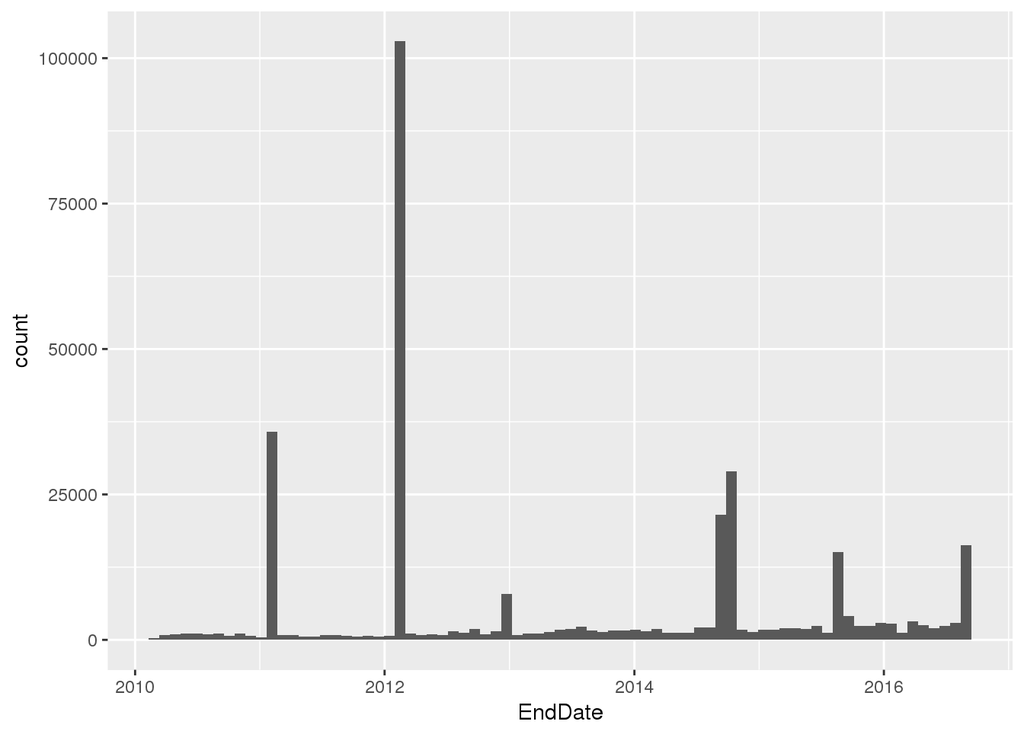

```r
scene_mbr_dim %>%
group_by(scene_mbr_acct_key) %>%
  summarise(EndDate=max(eff_to_tmstamp)) %>%
  ggplot(aes(x=EndDate)) +
  geom_histogram(bins = 77)
```

```r
EndDateTbl <- scene_mbr_dim %>%
group_by(scene_mbr_acct_key) %>%
  summarise(EndDate=max(eff_to_tmstamp))

scene_mbr_dim %>%
group_by(scene_mbr_acct_key) %>%
  summarise(EndDate=max(eff_to_tmstamp)) %>%
  filter(EndDate>ymd(20160101))
```

```
## # A tibble: 34,976 x 2
##    scene_mbr_acct_key             EndDate
##                 <int>              <dttm>
##  1                 12 2016-08-03 02:12:50
##  2                 62 2016-08-19 00:41:51
##  3                755 2016-08-19 00:41:52
##  4                980 2016-08-19 00:41:51
##  5               1092 2016-02-26 23:20:06
##  6               1260 2016-08-23 23:46:20
##  7               1314 2016-08-19 00:41:51
##  8               1916 2016-02-08 23:01:05
##  9               2079 2016-08-19 00:41:52
## 10               2159 2016-06-06 16:30:13
## # ... with 34,966 more rows
```

```r
group_by(EndDateTbl, year(EndDate))%>%
  summarise(count=n(),percentage = n()/nrow(EndDateTbl))
```

```
## # A tibble: 8 x 3
##   `year(EndDate)`  count   percentage
##             <dbl>  <int>        <dbl>
## 1            2010   8971 2.716723e-02
## 2            2011  42842 1.297401e-01
## 3            2012 114996 3.482469e-01
## 4            2013  24162 7.317073e-02
## 5            2014  66046 2.000097e-01
## 6            2015  38220 1.157431e-01
## 7            2016  34976 1.059192e-01
## 8              NA      1 3.028339e-06
```

35% of the customers were never renewed after their expiry in 2012. Also, the proportion of customers effective after January 1, 2016 was only around 11%.

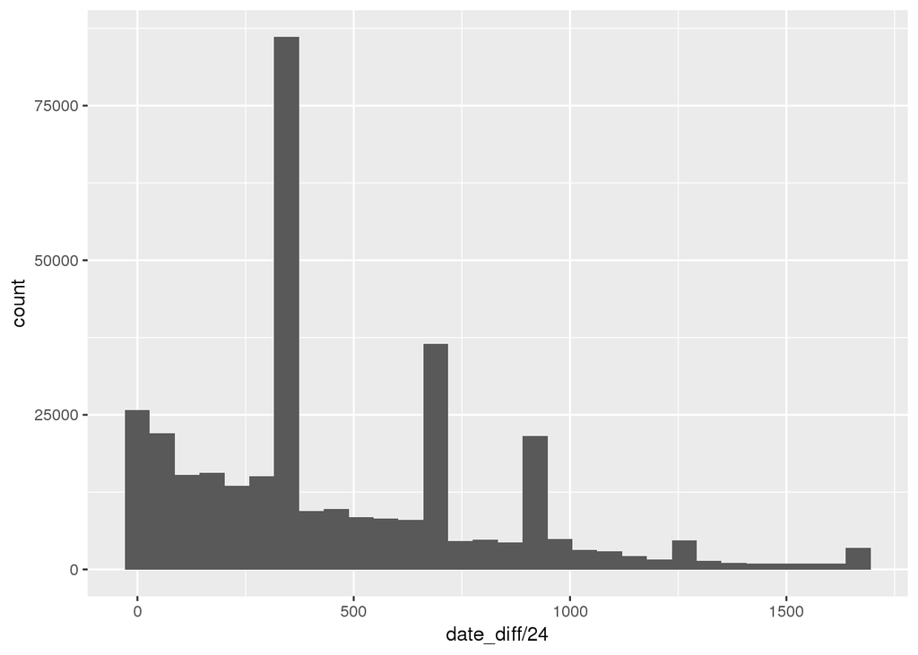

```r
scene_mbr_dim %>%
  mutate(date_diff=eff_to_tmstamp-eff_from_tmstamp) %>%
  select(date_diff) %>%
  ggplot(aes(x=date_diff/24)) +
  geom_histogram()
```

Each sequence number can be effective for any range of values. However, the typical values are 1 year and two years.

## Birth Date (brth_dt)

Birthday of the SCENE member, year only.

```r
summary(scene_mbr_dim$brth_dt)
```

```
##    Min. 1st Qu.  Median    Mean 3rd Qu.    Max.    NA's
##    1901    1968    1981    1977    1989    2011     730
```

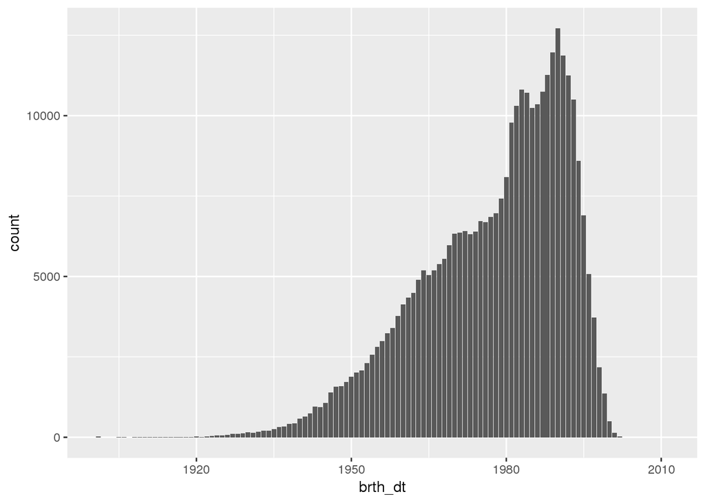

```r
ggplot(data = scene_mbr_dim, mapping = aes(x=brth_dt))+
  geom_bar()
```

## Postal Code (psnl_post_cd)

The postal code of the address. First 3 characters only.

```r
group_by(scene_mbr_dim, scene_mbr_acct_key, psnl_post_cd)%>%
  summarise(count=n())%>%
  group_by(psnl_post_cd)%>%
  summarise(count1=n())%>%
  arrange(desc(count1))
```

```
## # A tibble: 1,931 x 2
##    psnl_post_cd count1
##           <chr>  <int>
##  1          L4N   1565
##  2          L5M   1502
##  3          M1B   1477
##  4          L6R   1332
##  5          L9T   1293
##  6          M2N   1285
##  7          K0K   1240
##  8          L6Y   1238
##  9          L5N   1181
## 10          V3S   1163
## # ... with 1,921 more rows
```

Plotting the data on the map using external file which maps postal codes to latitude and longitude.

```r
postal_codes<-read_csv('/global/project/queens-mma/ca_postal_codes.csv')
```

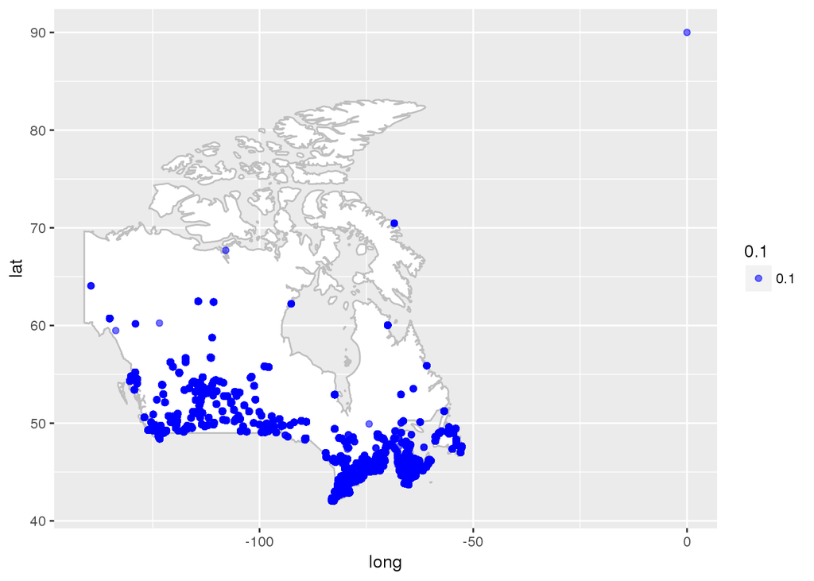

```r
# renaming column
colnames(postal_codes)[1]<-"PostalCode"
colnames(postal_codes)[2]<-"PlaceName"

#joining with main file
scene_mbr_dim<-
left_join(scene_mbr_dim, postal_codes, by=c("psnl_post_cd"="PostalCode"))

# install.packages('ggmap')
#library(ggmap)
# can_map <- get_map(location="Canada", zoom=3, maptype="terrain")

# ggmap(can_map,extent="normal") +
#  geom_point(data = scene_mbr_dim, aes(x = Longitude, y = Latitude, alpha = 0.3)) + scale_size_continuous(range = c(1,6))

library(maps)
can_map <- map_data("world", "Canada")

ggplot() +
  geom_polygon(data = can_map, aes(long, lat, group = group), fill = "white", colour = "grey") +
  geom_point(data = scene_mbr_dim, aes(x = Longitude, y = Latitude, alpha = 0.1), colour = "blue") +
  scale_size_continuous(range = c(1,6))
```

Distribution of scene members seem generally consistent to the Canadian population. One member, however, seems to have H0H (postal code for Santa Claus, no kidding!) as address. This could be a mistake or some interesting special account??

```r
Santa_Claus <- scene_mbr_dim %>%
  filter(psnl_post_cd == "H0H")
```

Looking at the account residing in postal code H0H, this is some 38-old French speaking dude (or a fictious test account maybe?) who prefers to watch movies at ‘Cineplex Odeon Place LaSalle’ (Montreal). Look for member key ‘2315422’ if interested…

## Personal Province State Code (psnl_prov_state_cd)

The state/province where the customer resides.

```r
summary(as.factor(scene_mbr_dim$psnl_prov_state_cd))
```

```
##     AB     BC     MB     NB     NL     NS     NT     NU     ON     PE
##  42854  44065  11331   2544   1903   4200    195      7 184207    506
##     QC     SK     YT   NA's
##  35356  10877     89      1
```

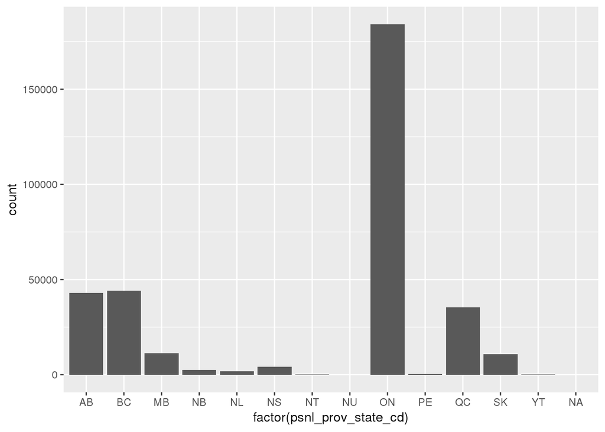

```r
ggplot(scene_mbr_dim, aes(x = factor(psnl_prov_state_cd))) +
  geom_bar()
```

Ontario members accounts for over half of the member base. Here’s a pie chart, just for fun.

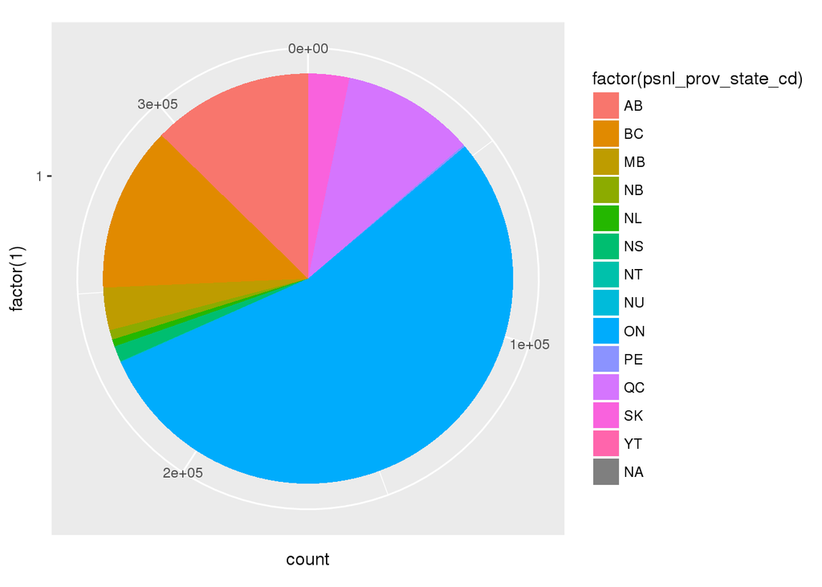

```r
ggplot(scene_mbr_dim, aes(x = factor(1), fill = factor(psnl_prov_state_cd))) +
  geom_bar(width = 1)+
  coord_polar(theta = "y")
```

## City (psnl_city)

The city of the address.

```r
length(unique(scene_mbr_dim$psnl_city))
```

```
## [1] 842
```

There are 842 unique cities represented in this sample.

Number of customers per city:

```r
scene_mbr_dim %>%
  group_by(psnl_city) %>%
  summarise(count= n(), percentage = n() / nrow(scene_mbr_dim)) %>%
  arrange(desc(count))
```

```
## # A tibble: 842 x 3
##      psnl_city count percentage
##          <chr> <int>      <dbl>
##  1     toronto 30832 0.09118252
##  2     calgary 14914 0.04410664
##  3 scarborough 11507 0.03403079
##  4    edmonton 11372 0.03363154
##  5 mississauga 10716 0.03169148
##  6    montreal  9917 0.02932852
##  7    winnipeg  8901 0.02632381
##  8    brampton  8900 0.02632085
##  9   vancouver  8571 0.02534786
## 10      ottawa  8519 0.02519408
## # ... with 832 more rows
```

## Suspended Flag (suspended_f)

Indicates whether the customer’s login has been suspended or not.

```r
scene_mbr_dim %>%
  group_by(suspended_f) %>%
  summarise(count= n(), percentage = n() / nrow(scene_mbr_dim)) %>%
  arrange(desc(count))
```

```
## # A tibble: 3 x 3
##   suspended_f  count   percentage
##         <int>  <int>        <dbl>
## 1           0 324375 9.593062e-01
## 2           1  13759 4.069085e-02
## 3          NA      1 2.957399e-06
```

4% customers have been suspended

## Gender (gndr_desc)

```r
scene_mbr_dim %>%
  group_by(gndr_desc) %>%
  summarise(count= n(), percentage = n() / nrow(scene_mbr_dim)) %>%
  arrange(desc(count))
```

```
## # A tibble: 5 x 3
##    gndr_desc  count   percentage
##        <chr>  <int>        <dbl>
## 1     Female 186632 5.519452e-01
## 2       Male 151316 4.475017e-01
## 3 Prefer not    153 4.524820e-04
## 4    Unknown     33 9.759416e-05
## 5       NULL      1 2.957399e-06
```

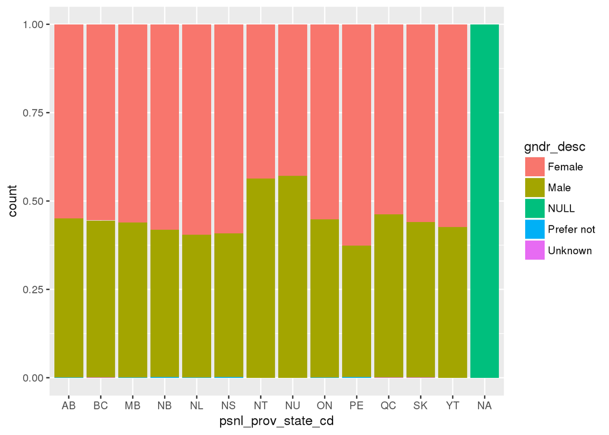

```r
group_by(scene_mbr_dim, psnl_prov_state_cd)%>%
  summarise(count= n())%>%
  left_join(scene_mbr_dim)%>%
  ggplot() + geom_bar(mapping=aes(x=psnl_prov_state_cd, fill = gndr_desc), position="fill")
```

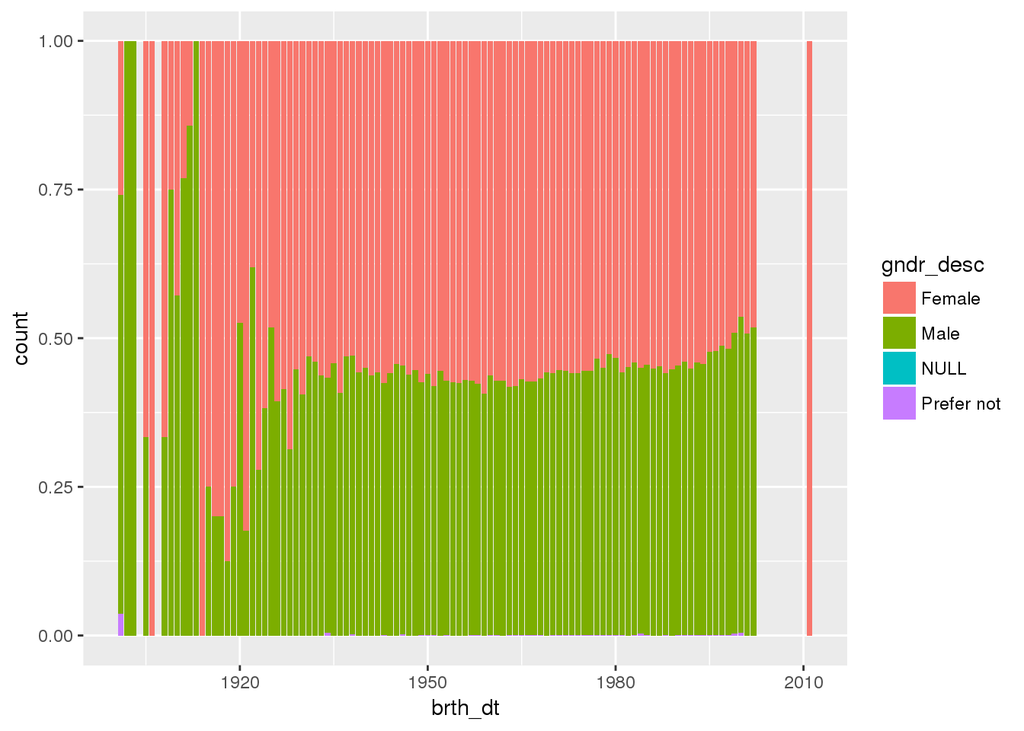

```r
group_by(scene_mbr_dim, brth_dt)%>%
  summarise(count= n())%>%
  left_join(scene_mbr_dim)%>%
  ggplot() + geom_bar(mapping=aes(x=brth_dt, fill = gndr_desc), position="fill")
```

55% of the members in the dataset are females. The ratio of female members are slightly higher than male members in most of Canadian Provinces. Yonger member base tend to have more male representation than do older members.

## Preferred Location

```r
group_by(scene_mbr_dim, prefrd_loctn_desc)%>%
  summarise(count=n_distinct(scene_mbr_key),percentage = n_distinct(scene_mbr_key) / n_distinct(scene_mbr_dim$scene_mbr_key))%>%
  arrange(desc(count))
```

```
## # A tibble: 156 x 3
##                                          prefrd_loctn_desc  count
##                                                      <chr>  <int>
##  1                                                 Unknown 190152
##  2                                         Coliseum Ottawa   2963
##  3                              Scotiabank Theatre Chinook   2944
##  4                                     SilverCity Yorkdale   2786
##  5 Scotiabank Theatre Toronto (formerly Paramount Toronto)   2745
##  6                                    Coliseum Mississauga   2647
##  7                                    SilverCity Polo Park   2553
##  8                                       SilverCity London   2468
##  9                           Cineplex Odeon South Edmonton   2461
## 10                                   SilverCity Metropolis   2298
## # ... with 146 more rows, and 1 more variables: percentage <dbl>
```

```r
scene_mbr_dim%>%
  filter(prefrd_loctn_desc!='Unknown')%>%
  group_by(psnl_city, prefrd_loctn_desc)%>%
  summarise(count=n_distinct(scene_mbr_acct_key))%>%
  arrange(desc(count))
```

```
## Source: local data frame [6,801 x 3]
## Groups: psnl_city [701]
##
## # A tibble: 6,801 x 3
##      psnl_city                                       prefrd_loctn_desc
##          <chr>                                                   <chr>
##  1     calgary                              Scotiabank Theatre Chinook
##  2     toronto                                     SilverCity Yorkdale
##  3 mississauga                                    Coliseum Mississauga
##  4     toronto Scotiabank Theatre Toronto (formerly Paramount Toronto)
##  5    winnipeg                                    SilverCity Polo Park
##  6    edmonton                           Cineplex Odeon South Edmonton
##  7    brampton                                     SilverCity Brampton
##  8   saskatoon                                Galaxy Cinemas Saskatoon
##  9     calgary                        Cineplex Odeon Sunridge Spectrum
## 10      london                                       SilverCity London
## # ... with 6,791 more rows, and 1 more variables: count <int>
```

## Email Preference (email_prefnc_desc)

Preferred format for emails

```r
group_by(scene_mbr_dim, email_prefnc_desc)%>%
  summarise(count=n(), percentage = n()/nrow(scene_mbr_dim))%>%
  arrange(desc(count))
```

```
## # A tibble: 4 x 3
##   email_prefnc_desc  count   percentage
##               <chr>  <int>        <dbl>
## 1              HTML 262987 7.777574e-01
## 2           Unknown  57564 1.702397e-01
## 3        Plain Text  17583 5.199994e-02
## 4              NULL      1 2.957399e-06
```

78% customers prefer HTML emails while 5% prefer plain text. 17% of preferences are unknown.

## Education Level

```r
group_by(scene_mbr_dim, ed_lvl_desc) %>%
  summarise(count=n(), percentage = n()/nrow(scene_mbr_dim))%>%
  arrange(desc(count))
```

```
## # A tibble: 11 x 3
##                                ed_lvl_desc  count   percentage
##                                      <chr>  <int>        <dbl>
##  1                                 Unknown 235050 6.951366e-01
##  2                   Completed High School  19554 5.782897e-02
##  3     Completed college, technical school  18697 5.529448e-02
##  4                    Completed University  17528 5.183728e-02
##  5          Some college, technical school  12574 3.718633e-02
##  6                         Some University  10109 2.989634e-02
##  7                       Prefer not to say   9422 2.786461e-02
##  8                        Some High School   8732 2.582401e-02
##  9 Some graduate school or graduate school   5889 1.741612e-02
## 10   Elementary school (less than grade 9)    579 1.712334e-03
## 11                                    NULL      1 2.957399e-06
```

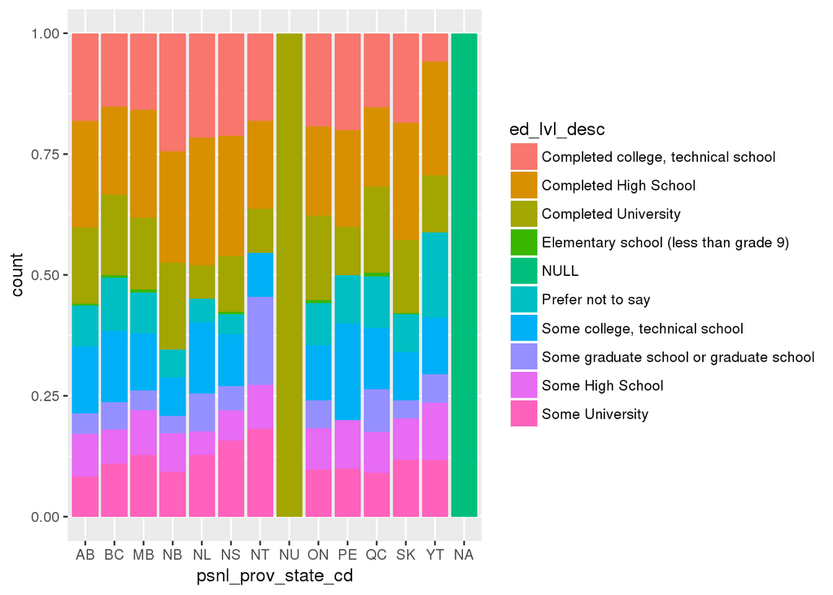

```r
group_by(scene_mbr_dim, psnl_prov_state_cd)%>%
  summarise(count= n())%>%
  left_join(scene_mbr_dim)%>%
  filter(ed_lvl_desc != "Unknown") %>%
  ggplot() + geom_bar(mapping=aes(x=psnl_prov_state_cd, fill = ed_lvl_desc), position="fill")
```

70% of the data is missing. Educational mix among members across provinces seem different.

## Preferred Show Time

```r
group_by(scene_mbr_dim, prefrd_show_tm_desc)%>%
  summarise(count=n(), percentage = n()/nrow(scene_mbr_dim))%>%
  arrange(desc(count))
```

```
## # A tibble: 13 x 3
##    prefrd_show_tm_desc  count  percentage
##                  <chr>  <int>       <dbl>
##  1                <NA> 196789 0.581983527
##  2              7:00pm  55575 0.164357431
##  3              9:00pm  23473 0.069419019
##  4              8:00pm  20677 0.061150132
##  5              6:00pm   9716 0.028734085
##  6             10:00pm   8144 0.024085055
##  7              4:00pm   5049 0.014931906
##  8              3:00pm   4755 0.014062431
##  9              1:00pm   4563 0.013494610
## 10              2:00pm   4398 0.013006639
## 11              5:00pm   3396 0.010043326
## 12         12 midnight    908 0.002685318
## 13             11:00pm    692 0.002046520
```

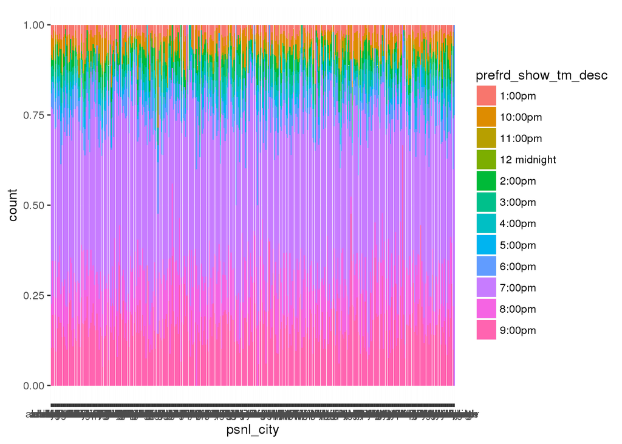

```r
group_by(scene_mbr_dim, psnl_city)%>%
  summarise(count= n())%>%
  arrange(desc(count))%>%
  filter(count>100)%>%
  left_join(scene_mbr_dim)%>%
  filter(prefrd_show_tm_desc!='Unknown')%>%
  ggplot()+
  geom_bar(mapping=aes(x=psnl_city, fill = prefrd_show_tm_desc), position="fill")
```

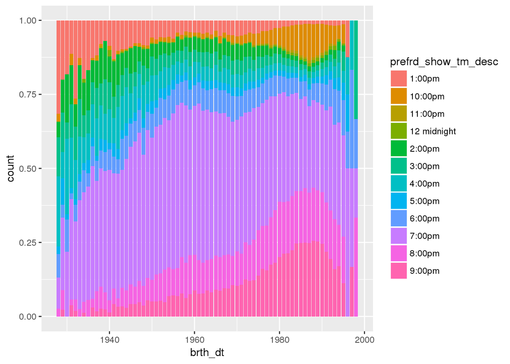

```r
group_by(scene_mbr_dim, brth_dt)%>%
  summarise(count= n())%>%
  arrange(desc(count))%>%
  filter(count>100)%>%
  left_join(scene_mbr_dim)%>%
  filter(prefrd_show_tm_desc!='Unknown')%>%
  ggplot()+
  geom_bar(mapping=aes(x=brth_dt, fill = prefrd_show_tm_desc), position="fill")
```

58% of the data is missing. Of the people who have responded, 7pm seems to be the preferred movie time (39%). Pereferred show time seem different across cities and age groups. As expected, yonger members tend to prefer later shows.

## Number of people in Household (num_of_hh_pple_desc)

```r
group_by(scene_mbr_dim, num_of_hh_pple_desc)%>%
  summarise(count=n(), percentage = n()/nrow(scene_mbr_dim))%>%
  arrange(desc(count))
```

```
## # A tibble: 8 x 3
##   num_of_hh_pple_desc  count   percentage
##                 <chr>  <int>        <dbl>
## 1               Unkno 192989 5.707454e-01
## 2                   1  51557 1.524746e-01
## 3                   2  28951 8.561965e-02
## 4                   4  26143 7.731527e-02
## 5                   3  19609 5.799163e-02
## 6                   5  12222 3.614533e-02
## 7                  6+   6663 1.970515e-02
## 8                NULL      1 2.957399e-06
```

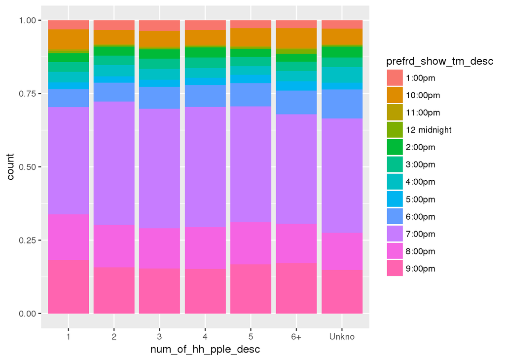

```r
scene_mbr_dim%>%
  filter(prefrd_show_tm_desc!="Unknown")%>%
  ggplot()+
  geom_bar(mapping=aes(x=num_of_hh_pple_desc, fill = prefrd_show_tm_desc), position="fill")
```

57% of the data is missing. Of the people who have responded, 35% are single person households. There is no significant variation in the preferred timing based on the number of people in the household. However, this variable can be used for classification as it can indicate the number of kids in the household and children can be targetted with specific genre. It can also indicate potential profit opportunity size.

## Movie Going Frequency (movie_gng_frq_ref_desc)

```r
group_by(scene_mbr_dim, movie_gng_frq_ref_desc)%>%
  summarise(count=n(),percentage = n()/nrow(scene_mbr_dim))%>%
  arrange(desc(count))
```

```
## # A tibble: 6 x 3
##   movie_gng_frq_ref_desc  count percentage
##                    <chr>  <int>      <dbl>
## 1                   <NA> 193665 0.57274461
## 2                    20+  36565 0.10813728
## 3                   7-10  36112 0.10679758
## 4                  11-20  33352 0.09863516
## 5                    3-6  31006 0.09169710
## 6                     <2   7435 0.02198826
```

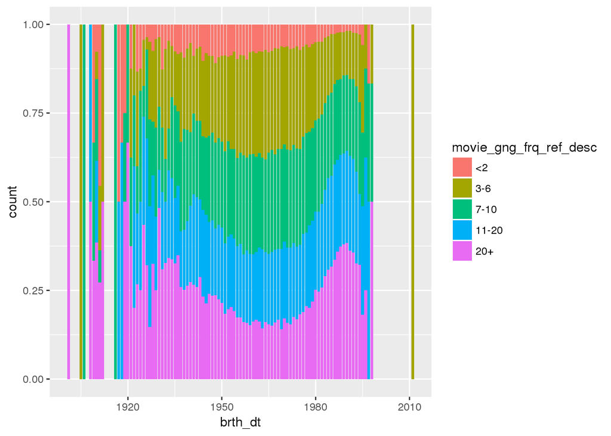

```r
movie_freq <- c("<2","3-6","7-10","11-20","20+")

scene_mbr_dim$movie_gng_frq_ref_desc<-
  factor(scene_mbr_dim$movie_gng_frq_ref_desc,levels=movie_freq, ordered=TRUE)

scene_mbr_dim%>%
  filter(movie_gng_frq_ref_desc !="NA")%>%
  ggplot()+
  geom_bar(mapping=aes(x=brth_dt, fill = movie_gng_frq_ref_desc), position="fill")
```

57% data missing. Customers are evenly spread over the frequency ranges 20+, 7-10, 11-20 and 3-6. As expected, younger members tend to watch more movies.

## Marital Status (mrtl_stat_desc)

```r
group_by(scene_mbr_dim, mrtl_stat_desc)%>%
  summarise(count=n(), percentage = n()/nrow(scene_mbr_dim))%>%
  arrange(desc(count))
```

```
## # A tibble: 7 x 3
##          mrtl_stat_desc  count   percentage
##                   <chr>  <int>        <dbl>
## 1               Unknown 125735 3.718485e-01
## 2                Single 117807 3.484023e-01
## 3 Married or Common Law  88856 2.627826e-01
## 4              Divorced   2620 7.748385e-03
## 5             Separated   2173 6.426427e-03
## 6               Widowed    943 2.788827e-03
## 7                  NULL      1 2.957399e-06
```

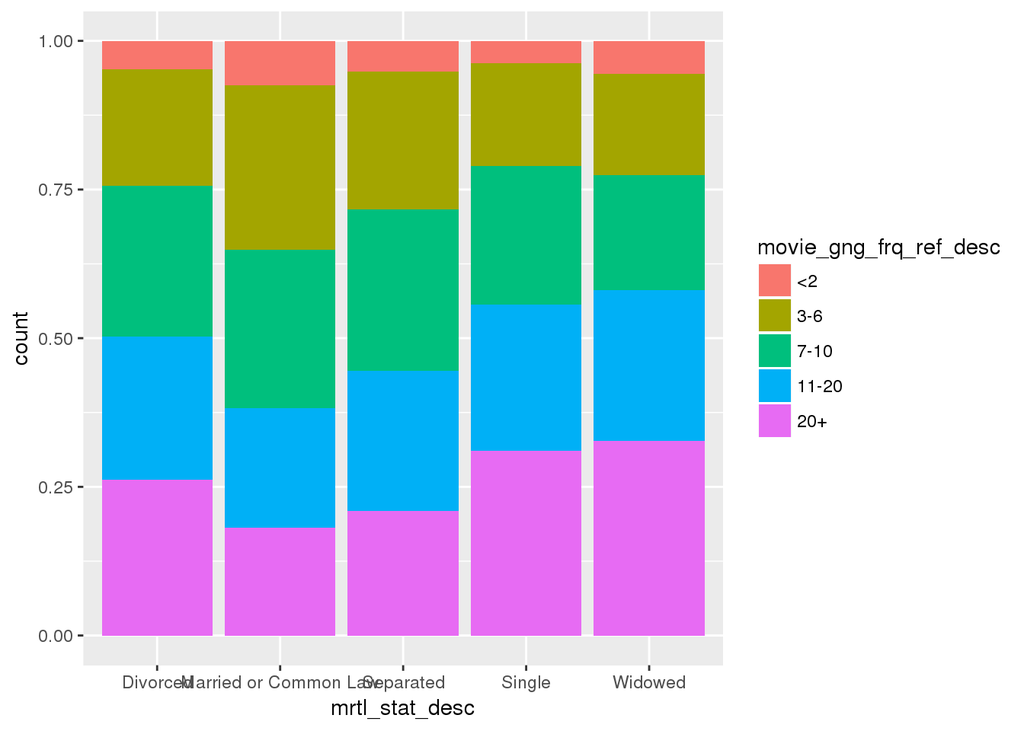

```r
scene_mbr_dim%>%
  filter(mrtl_stat_desc!='Unknown'&movie_gng_frq_ref_desc!='Unknown')%>%
  ggplot()+
  geom_bar(mapping=aes(x=mrtl_stat_desc, fill = movie_gng_frq_ref_desc), position="fill")
```

37% data missing, 35% singles and 26% married or common law. Married or common in law members tend to watch less movies compare to other groups.

## Language (lang_desc)

Preferred language

```r
group_by(scene_mbr_dim, lang_desc)%>%
  summarise(count=n(),percentage = n()/nrow(scene_mbr_dim))%>%
  arrange(desc(count))
```

```
## # A tibble: 4 x 3
##   lang_desc  count   percentage
##       <chr>  <int>        <dbl>
## 1   English 311645 9.216585e-01
## 2    French  25164 7.441998e-02
## 3   Unknown   1325 3.918553e-03
## 4      NULL      1 2.957399e-06
```

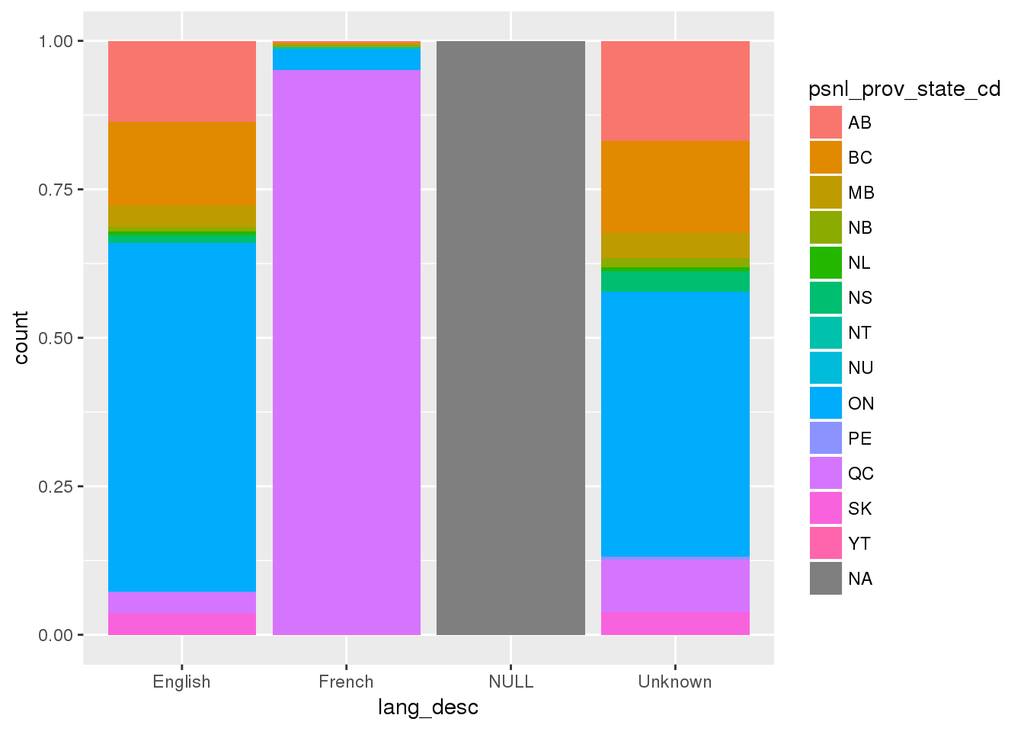

```r
group_by(scene_mbr_dim, lang_desc)%>%
  summarise(count= n())%>%
  arrange(desc(count))%>%
  left_join(scene_mbr_dim)%>%
  ggplot()+
  geom_bar(mapping=aes(x=lang_desc, fill = psnl_prov_state_cd), position="fill")
```

Over 90% of the customers have English as the preferred language. As expected, vast majority of Francophone members are from Quebect.

## Scene Activity Status (scene_acty_stat)

0 = Unconfirmed - Members are Unconfirmed by default. These members have not had points expired, but they can be considered for points expiry. 1 = Confirmed Active - Members that are Confirmed Active are not to have points expired. 2 = Dormant - Members that are Dormant have had their points expired

```r
group_by(scene_mbr_dim, scene_acty_stat)%>%
  summarise(count=n(),percentage = n()/nrow(scene_mbr_dim))%>%
  arrange(desc(count))
```

```
## # A tibble: 4 x 3
##   scene_acty_stat  count  percentage
##             <chr>  <int>       <dbl>
## 1               0 164502 0.486497996
## 2            NULL 160748 0.475395922
## 3               2  10582 0.031295193
## 4               1   2303 0.006810889
```

48% of the data is missing and 49% data is “Unconfirmed”.

# Table: scene_member_acct_dim

This table holds data on member accounts. Each member (from the above `scene_mbr_dim` table) belongs to a member account. Think of it like a family: there would be one account, but many members belonging to that account.

```r
scene_mbr_acct_dim <- read_csv(paste(in_path, 'scene_mbr_acct_dim.csv', sep=""))
```

Here are the details of the table:

```r
dim(scene_mbr_acct_dim)
```

```
## [1] 330212      7
```

```r
colnames(scene_mbr_acct_dim)
```

```
## [1] "scene_mbr_acct_key"      "enrollment_stat_cd"
## [3] "prim_scene_mbr_key"      "cncl_dt"
## [5] "scene_src_enrollment_dt" "acct_eff_from_tmstamp"
## [7] "date_lag"
```

```r
str(scene_mbr_acct_dim)
```

```
## Classes 'tbl_df', 'tbl' and 'data.frame':    330212 obs. of  7 variables:
##  $ scene_mbr_acct_key     : int  8 167 69 2085 2586 3729 3665 4825 6033 6094 ...
##  $ enrollment_stat_cd     : chr  "E" "E" "E" "E" ...
##  $ prim_scene_mbr_key     : int  3333932 2253792 2926987 2911940 3163859 2868484 3207257 3914259 2256116 3799033 ...
##  $ cncl_dt                : POSIXct, format: NA NA ...
##  $ scene_src_enrollment_dt: POSIXct, format: "2006-12-12 09:28:53" "2006-12-17 19:05:50" ...
##  $ acct_eff_from_tmstamp  : POSIXct, format: "2010-03-03 21:38:34" "2010-03-03 21:38:34" ...
##  $ date_lag               : num  1178 1172 2780 1134 2135 ...
##  - attr(*, "spec")=List of 2
##   ..$ cols   :List of 7
##   .. ..$ scene_mbr_acct_key     : list()
##   .. .. ..- attr(*, "class")= chr  "collector_integer" "collector"
##   .. ..$ enrollment_stat_cd     : list()
##   .. .. ..- attr(*, "class")= chr  "collector_character" "collector"
##   .. ..$ prim_scene_mbr_key     : list()
##   .. .. ..- attr(*, "class")= chr  "collector_integer" "collector"
##   .. ..$ cncl_dt                :List of 1
##   .. .. ..$ format: chr ""
##   .. .. ..- attr(*, "class")= chr  "collector_datetime" "collector"
##   .. ..$ scene_src_enrollment_dt:List of 1
##   .. .. ..$ format: chr ""
##   .. .. ..- attr(*, "class")= chr  "collector_datetime" "collector"
##   .. ..$ acct_eff_from_tmstamp  :List of 1
##   .. .. ..$ format: chr ""
##   .. .. ..- attr(*, "class")= chr  "collector_datetime" "collector"
##   .. ..$ date_lag               : list()
##   .. .. ..- attr(*, "class")= chr  "collector_double" "collector"
##   ..$ default: list()
##   .. ..- attr(*, "class")= chr  "collector_guess" "collector"
##   ..- attr(*, "class")= chr "col_spec"
```

```r
summary(scene_mbr_acct_dim)
```

```
##  scene_mbr_acct_key enrollment_stat_cd prim_scene_mbr_key
##  Min.   :      7    Length:330212      Min.   : 2245019
##  1st Qu.:1216802    Class :character   1st Qu.: 3388569
##  Median :2306549    Mode  :character   Median : 4551566
##  Mean   :2820286                       Mean   : 5046768
##  3rd Qu.:4129224                       3rd Qu.: 6374178
##  Max.   :8978272                       Max.   :11241506
##
##     cncl_dt                    scene_src_enrollment_dt
##  Min.   :2007-11-22 16:55:46   Min.   :2006-12-11 23:12:16
##  1st Qu.:2011-07-20 12:58:59   1st Qu.:2008-10-16 00:00:00
##  Median :2013-07-19 20:14:58   Median :2010-03-30 00:00:00
##  Mean   :2013-02-03 15:14:45   Mean   :2010-08-30 10:07:34
##  3rd Qu.:2014-12-04 04:12:07   3rd Qu.:2012-06-20 00:00:00
##  Max.   :2016-09-07 14:22:07   Max.   :2016-09-03 00:00:00
##  NA's   :325061
##  acct_eff_from_tmstamp            date_lag
##  Min.   :2010-03-03 21:38:34   Min.   :   0.245
##  1st Qu.:2010-03-03 21:43:24   1st Qu.:   1.966
##  Median :2011-01-26 23:15:32   Median : 139.906
##  Mean   :2011-10-25 21:22:37   Mean   : 421.469
##  3rd Qu.:2013-04-01 22:30:28   3rd Qu.: 669.067
##  Max.   :2016-09-09 00:03:41   Max.   :3496.991
##
```

Here are the first 20 rows of the data:

```r
head(scene_mbr_acct_dim, n=20)
```

```
## # A tibble: 20 x 7
##    scene_mbr_acct_key enrollment_stat_cd prim_scene_mbr_key             cncl_dt
##                 <int>              <chr>              <int>              <dttm>
##  1                  8                  E            3333932                  NA
##  2                167                  E            2253792                  NA
##  3                 69                  E            2926987                  NA
##  4               2085                  E            2911940                  NA
##  5               2586                  U            3163859 2012-08-18 14:48:01
##  6               3729                  E            2868484                  NA
##  7               3665                  E            3207257                  NA
##  8               4825                  E            3914259                  NA
##  9               6033                  E            2256116                  NA
## 10               6094                  E            3799033                  NA
## 11               5581                  E            3869828                  NA
## 12                941                  E            2253982                  NA
## 13               2005                  E            2254868                  NA
## 14               7036                  E            2256873                  NA
## 15               7327                  E            3341794                  NA
## 16               7996                  E            3622647                  NA
## 17              10127                  E            3621983                  NA
## 18               6954                  E            3326808                  NA
## 19               7966                  E            2254380                  NA
## 20               9188                  E            3570431                  NA
## # ... with 3 more variables: scene_src_enrollment_dt <dttm>,
## #   acct_eff_from_tmstamp <dttm>, date_lag <dbl>
```

## Enrollment Status Code (enrollment_stat_cd)

Possible values: - `E` = Enrolled - `U` = Unenrolled - `P` = Pending - `C` = Canceled

```r
group_by(scene_mbr_acct_dim, enrollment_stat_cd)%>%
  summarise(count=n(),percentage = n()/nrow(scene_mbr_acct_dim))%>%
  arrange(desc(count))
```

```
## # A tibble: 3 x 3
##   enrollment_stat_cd  count   percentage
##                <chr>  <int>        <dbl>
## 1                  E 325020 0.9842767677
## 2                  U   5098 0.0154385667
## 3                  C     94 0.0002846656
```

## cncl_dt

Cancel date. 98% of the field is ‘null’.

```r
scene_mbr_acct_dim$cncl_dt <- ymd_hms(scene_mbr_acct_dim$cncl_dt)

group_by(scene_mbr_acct_dim, cncl_dt)%>%
  summarise(count=n(),percentage = n()/nrow(scene_mbr_acct_dim))%>%
  arrange(desc(count))
```

```
## # A tibble: 4,796 x 3
##                cncl_dt  count   percentage
##                 <dttm>  <int>        <dbl>
##  1                  NA 325061 9.844009e-01
##  2 2007-12-17 15:14:15    229 6.934939e-04
##  3 2007-12-17 20:40:17     31 9.387908e-05
##  4 2012-10-25 15:18:26      7 2.119850e-05
##  5 2014-02-19 15:34:41      7 2.119850e-05
##  6 2012-10-25 15:18:27      6 1.817015e-05
##  7 2012-10-25 15:18:32      5 1.514179e-05
##  8 2012-10-25 15:18:35      5 1.514179e-05
##  9 2014-01-23 16:27:07      5 1.514179e-05
## 10 2014-01-23 16:26:59      4 1.211343e-05
## # ... with 4,786 more rows
```

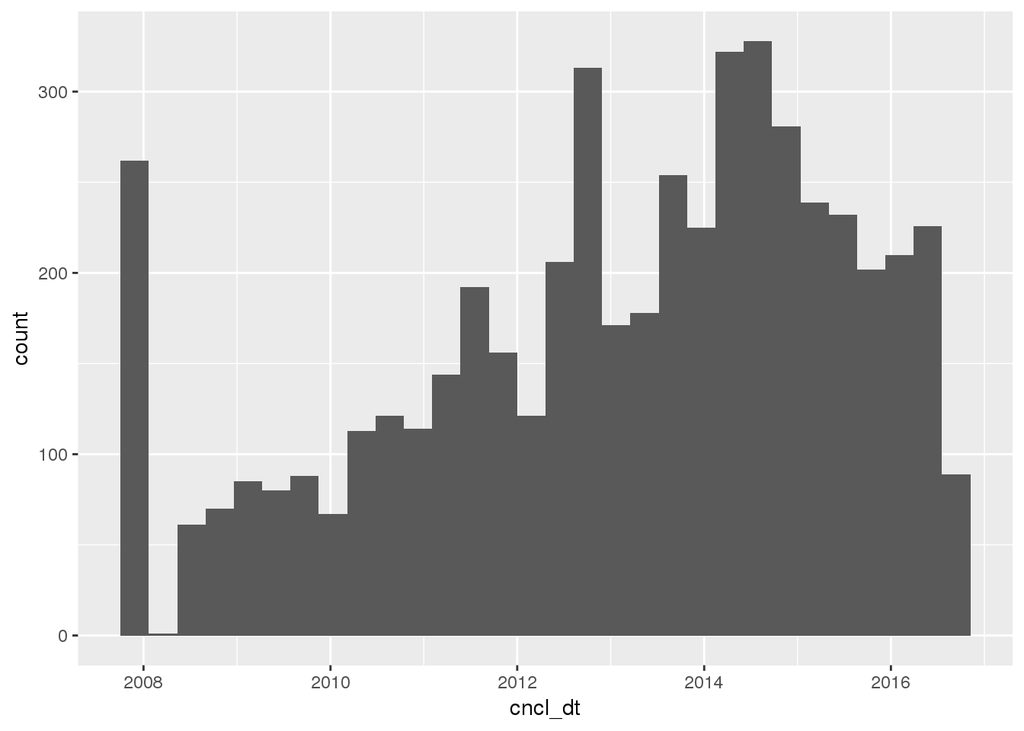

```r
scene_mbr_acct_dim%>%
  filter(!is.na(cncl_dt))%>%
  ggplot(aes(x=cncl_dt))+
  geom_histogram()
```

98% of the field is ‘null’, which is expected as most people would not call in to cancel a loyalty account even if they no longer use it. The number of cancellation seems to be increasing over time. However, this could be misleading as we might see the number of accounts growing over time as well. We should look at cancellation in conjunction with the number of accounts over time. Comparing the number of accounts having a cancel date with enrollment status above, ‘U’ and ‘C’ seem to be equivalent.

## Enrollment Date (scene_src_enrollment_dt)

Original member enrollment Date sourced from Maritz.

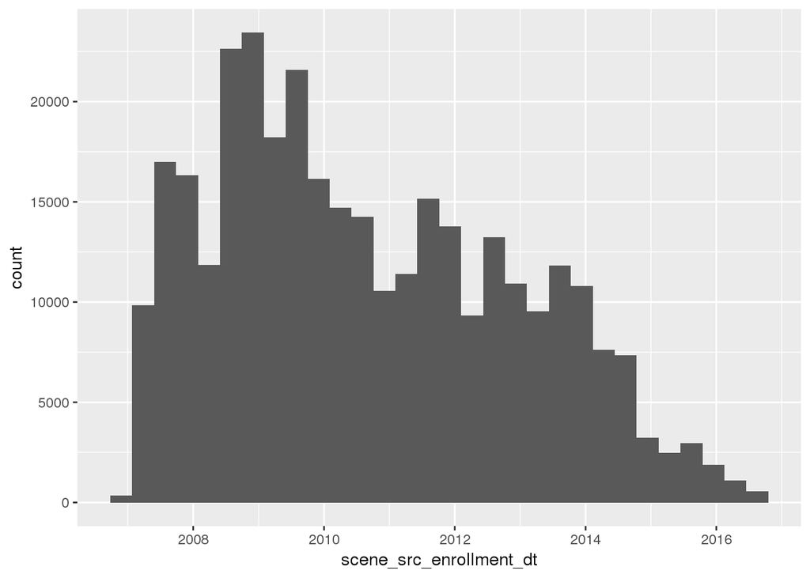

```r
scene_mbr_acct_dim%>%
  ggplot(aes(x=scene_src_enrollment_dt))+
  geom_histogram()
```

The number of enrollment seems to have significantly dropped since 2014, which seem unintuitive. A possibility that could exlain what we see here is the time lag between when an account is enrolled vs. when the data enters into the database we are using. See next point below.

## acct_eff_from_tmstamp

Date from which that specific record became effective.

```r
group_by(scene_mbr_acct_dim, as.Date(acct_eff_from_tmstamp))%>%
  summarise(count=n(),percentage = n()/nrow(scene_mbr_acct_dim))%>%
  arrange(desc(count))
```

```
## # A tibble: 1,704 x 3
##    `as.Date(acct_eff_from_tmstamp)`  count  percentage
##                              <date>  <int>       <dbl>
##  1                       2010-03-03 132313 0.400691071
##  2                       2014-11-26   1121 0.003394789
##  3                       2011-09-20   1026 0.003107095
##  4                       2016-06-06   1004 0.003040471
##  5                       2011-12-19    731 0.002213729
##  6                       2013-01-31    724 0.002192531
##  7                       2011-07-20    657 0.001989631
##  8                       2010-03-08    602 0.001823071
##  9                       2012-09-07    602 0.001823071
## 10                       2011-12-17    564 0.001707994
## # ... with 1,694 more rows
```

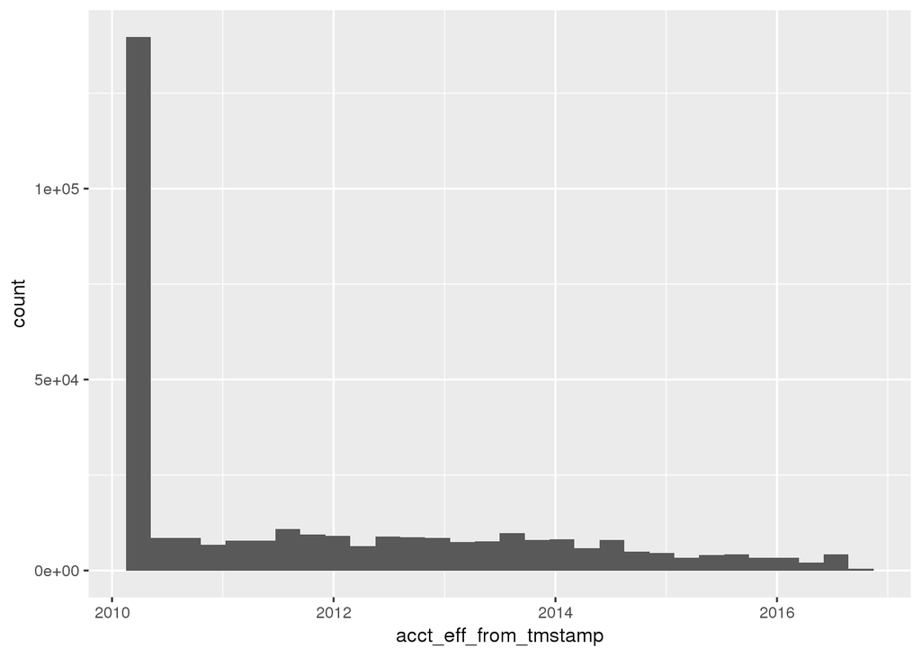

```r
scene_mbr_acct_dim%>%
  ggplot(aes(x=acct_eff_from_tmstamp))+
  geom_histogram()
```

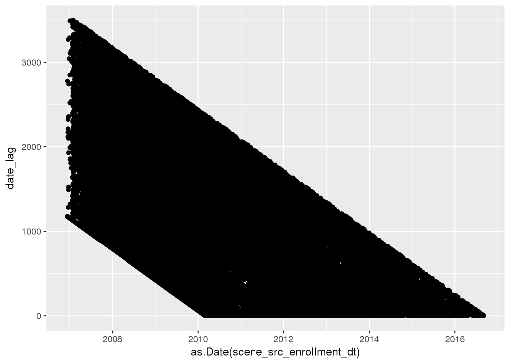

```r
ggplot(data=scene_mbr_acct_dim) +
  geom_point(mapping = aes(x=as.Date(scene_src_enrollment_dt),y= date_lag))
```

Approximatly 40% of accounts in the tiny dataset have an effective date of 2010-03-03. This seems to be the date where enrollment data (from Maritz) started to be ingested into a new database. The range of date lag between the original enrollment date and account effective date decreases linearly as time progresses. This further confirms the theory above–newly enrolled account might experience a range of lags before they are reflected in this database.

# Table: scene_pt_fact

```r
scene_pt_fact <- read_csv(paste(in_path, 'scene_pt_fact.csv', sep=""))
```

Here are the details of the table:

```r
dim(scene_pt_fact)
```

```
## [1] 16784588       19
```

```r
colnames(scene_pt_fact)
```

```
##  [1] "pt"                 "txn_amt"            "scene_pt_tp_key"
##  [4] "scene_mbr_acct_key" "scene_mbr_key"      "mth_tm_key"
##  [7] "cd"                 "nm"                 "desc"
## [10] "txn_src"            "txn_tp_1"           "txn_tp_2"
## [13] "txn_tp_3"           "scene_pt_tp_dim_R"  "anul_clndr_code"
## [16] "anul_fncl_code"     "mo_clndr_code"      "time_lvl_st_dt"
## [19] "time_lvl_end_dt"
```

```r
str(scene_pt_fact)
```

```
## Classes 'tbl_df', 'tbl' and 'data.frame':    16784588 obs. of  19 variables:
##  $ pt                : int  250 250 250 250 250 250 250 250 250 250 ...
##  $ txn_amt           : chr  NA NA NA NA ...
##  $ scene_pt_tp_key   : int  2 2 2 2 2 2 2 2 2 2 ...
##  $ scene_mbr_acct_key: int  40480 42195 54264 55458 70924 72447 74919 87167 89026 94336 ...
##  $ scene_mbr_key     : int  2972278 3223061 3854667 2913198 2268783 2249584 3562020 2792624 2276417 3874409 ...
##  $ mth_tm_key        : int  12036 12036 12076 12076 12116 12116 12116 12116 12116 12116 ...
##  $ cd                : chr  "EBNS" "EBNS" "EBNS" "EBNS" ...
##  $ nm                : chr  "Enrollment Bonus" "Enrollment Bonus" "Enrollment Bonus" "Enrollment Bonus" ...
##  $ desc              : chr  "SCENE Enrollment Bonus" "SCENE Enrollment Bonus" "SCENE Enrollment Bonus" "SCENE Enrollment Bonus" ...
##  $ txn_src           : chr  "SCE" "SCE" "SCE" "SCE" ...
##  $ txn_tp_1          : chr  "issuance" "issuance" "issuance" "issuance" ...
##  $ txn_tp_2          : chr  "enrollbonus" "enrollbonus" "enrollbonus" "enrollbonus" ...
##  $ txn_tp_3          : chr  "unknown" "unknown" "unknown" "unknown" ...
##  $ scene_pt_tp_dim_R : int  2 2 2 2 2 2 2 2 2 2 ...
##  $ anul_clndr_code   : int  2007 2007 2007 2007 2007 2007 2007 2007 2007 2007 ...
##  $ anul_fncl_code    : int  2007 2007 2007 2007 2007 2007 2007 2007 2007 2007 ...
##  $ mo_clndr_code     : chr  "March" "March" "April" "April" ...
##  $ time_lvl_st_dt    : Date, format: "2007-03-01" "2007-03-01" ...
##  $ time_lvl_end_dt   : Date, format: "2007-03-31" "2007-03-31" ...
##  - attr(*, "problems")=Classes 'tbl_df', 'tbl' and 'data.frame': 4 obs. of  5 variables:
##   ..$ row     : int  944071 2445612 7858987 8311169
##   ..$ col     : chr  "pt" "pt" "pt" "pt"
##   ..$ expected: chr  "no trailing characters" "no trailing characters" "no trailing characters" "no trailing characters"
##   ..$ actual  : chr  "e+05" ".6" ".8" ".2"
##   ..$ file    : chr  "'/global/project/queens-mma/scene-csv/sample03/clean/scene_pt_fact.csv'" "'/global/project/queens-mma/scene-csv/sample03/clean/scene_pt_fact.csv'" "'/global/project/queens-mma/scene-csv/sample03/clean/scene_pt_fact.csv'" "'/global/project/queens-mma/scene-csv/sample03/clean/…
##  - attr(*, "spec")=List of 2
##   ..$ cols   :List of 19
##   .. ..$ pt                : list()
##   .. .. ..- attr(*, "class")= chr  "collector_integer" "collector"
##   .. ..$ txn_amt           : list()
##   .. .. ..- attr(*, "class")= chr  "collector_character" "collector"
##   .. ..$ scene_pt_tp_key   : list()
##   .. .. ..- attr(*, "class")= chr  "collector_integer" "collector"
##   .. ..$ scene_mbr_acct_key: list()
##   .. .. ..- attr(*, "class")= chr  "collector_integer" "collector"
##   .. ..$ scene_mbr_key     : list()
##   .. .. ..- attr(*, "class")= chr  "collector_integer" "collector"
##   .. ..$ mth_tm_key        : list()
##   .. .. ..- attr(*, "class")= chr  "collector_integer" "collector"
```

[output cut: 16 more lines]

```
##   .. ..$ anul_clndr_code   : list()
##   .. .. ..- attr(*, "class")= chr  "collector_integer" "collector"
##   .. ..$ anul_fncl_code    : list()
##   .. .. ..- attr(*, "class")= chr  "collector_integer" "collector"
##   .. ..$ mo_clndr_code     : list()
##   .. .. ..- attr(*, "class")= chr  "collector_character" "collector"
##   .. ..$ time_lvl_st_dt    :List of 1
##   .. .. ..$ format: chr ""
##   .. .. ..- attr(*, "class")= chr  "collector_date" "collector"
##   .. ..$ time_lvl_end_dt   :List of 1
##   .. .. ..$ format: chr ""
##   .. .. ..- attr(*, "class")= chr  "collector_date" "collector"
##   ..$ default: list()
##   .. ..- attr(*, "class")= chr  "collector_guess" "collector"
##   ..- attr(*, "class")= chr "col_spec"
```

```r
summary(scene_pt_fact)
```

```
##        pt               txn_amt          scene_pt_tp_key
##  Min.   :-126000.00   Length:16784588    Min.   :    1
##  1st Qu.:     25.00   Class :character   1st Qu.:    4
##  Median :    100.00   Mode  :character   Median :   18
##  Mean   :     48.33                      Mean   : 2505
##  3rd Qu.:    225.00                      3rd Qu.:   18
##  Max.   : 179515.00                      Max.   :50001
##  NA's   :4
##  scene_mbr_acct_key scene_mbr_key        mth_tm_key         cd
##  Min.   :      7    Min.   : 2245019   Min.   :11916   Length:16784588
##  1st Qu.: 820313    1st Qu.: 3095573   1st Qu.:14036   Class :character
##  Median :1660347    Median : 3950186   Median :15076   Mode  :character
##  Mean   :2070370    Mean   : 4339944   Mean   :14923
##  3rd Qu.:2804482    3rd Qu.: 5049634   3rd Qu.:15916
##  Max.   :8978272    Max.   :11241506   Max.   :16596
##
##       nm                desc             txn_src
##  Length:16784588    Length:16784588    Length:16784588
##  Class :character   Class :character   Class :character
##  Mode  :character   Mode  :character   Mode  :character
##
##
##
##
##    txn_tp_1           txn_tp_2           txn_tp_3
##  Length:16784588    Length:16784588    Length:16784588
##  Class :character   Class :character   Class :character
##  Mode  :character   Mode  :character   Mode  :character
##
##
##
##
##  scene_pt_tp_dim_R anul_clndr_code anul_fncl_code mo_clndr_code
##  Min.   :    1     Min.   :2006    Min.   :2007   Length:16784588
##  1st Qu.:    4     1st Qu.:2011    1st Qu.:2011   Class :character
##  Median :   18     Median :2013    Median :2013   Mode  :character
##  Mean   : 2505     Mean   :2013    Mean   :2013
##  3rd Qu.:   18     3rd Qu.:2015    3rd Qu.:2015
##  Max.   :50001     Max.   :2016    Max.   :2016
##
##  time_lvl_st_dt       time_lvl_end_dt
##  Min.   :2006-12-01   Min.   :2006-12-31
##  1st Qu.:2011-05-01   1st Qu.:2011-05-31
##  Median :2013-07-01   Median :2013-07-31
##  Mean   :2013-03-06   Mean   :2013-04-05
##  3rd Qu.:2015-04-01   3rd Qu.:2015-04-30
##  Max.   :2016-09-01   Max.   :2016-09-30
##
```

Here are the first 20 rows of the data:

```r
head(scene_pt_fact, n=20)
```

```
## # A tibble: 20 x 19
##       pt txn_amt scene_pt_tp_key scene_mbr_acct_key scene_mbr_key
##    <int>   <chr>           <int>              <int>         <int>
##  1   250    <NA>               2              40480       2972278
##  2   250    <NA>               2              42195       3223061
##  3   250    <NA>               2              54264       3854667
##  4   250    <NA>               2              55458       2913198
##  5   250    <NA>               2              70924       2268783
##  6   250    <NA>               2              72447       2249584
##  7   250    <NA>               2              74919       3562020
##  8   250    <NA>               2              87167       2792624
##  9   250    <NA>               2              89026       2276417
## 10   250    <NA>               2              94336       3874409
## 11   250    <NA>               2             118757       2280933
## 12   250    <NA>               2             138576       2253339
## 13   250    <NA>               2             148883       4108425
## 14   250    <NA>               2             150586       4091119
## 15   250    <NA>               2             190764       3500424
## 16   250    <NA>               2             202640       3499803
## 17   250    <NA>               2             203991       3272303
## 18   250    <NA>               2             212775       2871412
## 19   250    <NA>               2             222732       2988530
## 20   250    <NA>               2             233465       3272031
## # ... with 14 more variables: mth_tm_key <int>, cd <chr>, nm <chr>,
## #   desc <chr>, txn_src <chr>, txn_tp_1 <chr>, txn_tp_2 <chr>,
## #   txn_tp_3 <chr>, scene_pt_tp_dim_R <int>, anul_clndr_code <int>,
## #   anul_fncl_code <int>, mo_clndr_code <chr>, time_lvl_st_dt <date>,
## #   time_lvl_end_dt <date>
```

## Points (pt) & Transaction Amount (txn_amt)

These are the number of points earned or deducted for each transaction. They may be: 1. Linked to a financial transaction, in which case the transaction column will have dollar value. 2. Linked to an event (such as new account, referral bonus, redemptions, etc.), in which case the transaction column will be `NULL`.

High level summary per customer:

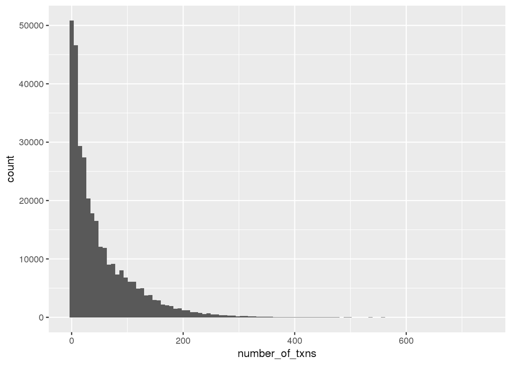

```r
summary<-
group_by(scene_pt_fact, scene_mbr_acct_key)%>%
  summarise(number_of_txns=n(),
            total_points= sum(pt),
            total_txn_amt= sum(as.numeric(txn_amt),na.rm=TRUE))%>%
  arrange(desc(total_points))

summary%>%
  ggplot(aes(x=number_of_txns))+
  geom_histogram(bins = 100)
```

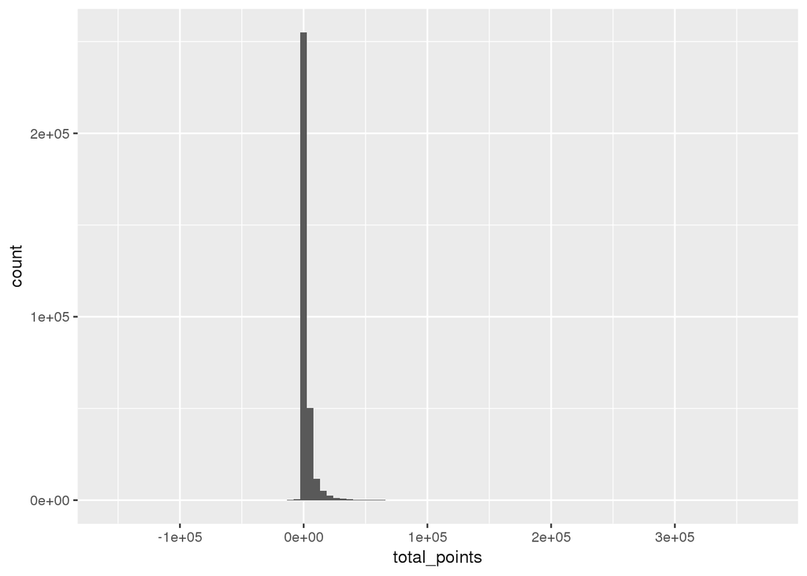

```r
summary%>%
  ggplot(aes(x=total_points))+
  geom_histogram(bins = 100)
```

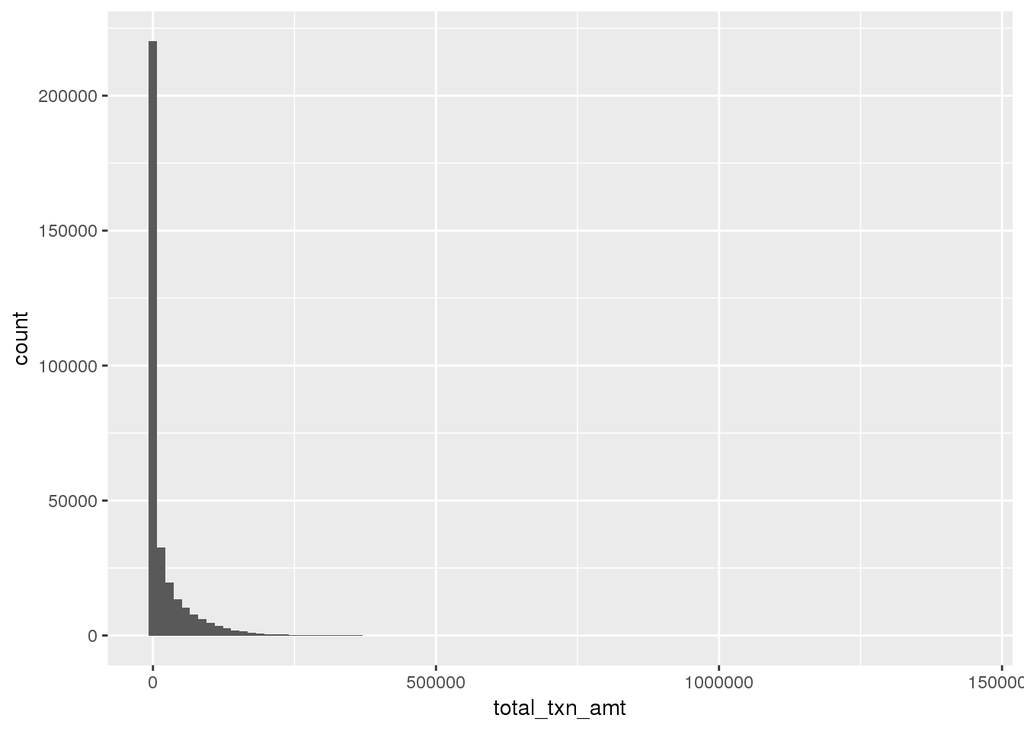

```r
summary%>%
  ggplot(aes(x=total_txn_amt))+
  geom_histogram(bins = 100)
```

Some high level count per transaction types

```r
group_by(scene_pt_fact, txn_tp_1)%>%
  summarise(count=n(),
            percent = count/length(scene_pt_fact$txn_tp_1)*100,
            avg_pts_txn = mean(as.numeric(pt), na.rm=TRUE),
            avg_dollar_txn = mean(as.numeric(txn_amt), na.rm=TRUE))%>%
  arrange(desc(count))
```

```
## # A tibble: 4 x 5
##       txn_tp_1    count     percent avg_pts_txn avg_dollar_txn
##          <chr>    <int>       <dbl>       <dbl>          <dbl>
## 1     issuance 15289066 91.08990939   213.94806      579.05829
## 2   redemption  1481482  8.82644245 -1659.87019      -37.17884
## 3     reversal    12447  0.07415732    22.50454      -42.60245
## 4 deactivation     1593  0.00949085  -699.68738            NaN
```

```r
group_by(scene_pt_fact, txn_tp_2)%>%
  summarise(count=n(),
            percent = count/length(scene_pt_fact$txn_tp_2)*100,
            avg_pts_txn = mean(as.numeric(pt), na.rm=TRUE),
            avg_dollar_txn = mean(as.numeric(txn_amt), na.rm=TRUE))%>%
  arrange(desc(count))
```

```
## # A tibble: 6 x 5
##       txn_tp_2    count      percent avg_pts_txn avg_dollar_txn
##          <chr>    <int>        <dbl>       <dbl>          <dbl>
## 1      regular 15930241 9.490993e+01    26.86399       597.0608
## 2  enrollbonus   572383 3.410170e+00   482.39360         0.0000
## 3   promobonus   280342 1.670235e+00   385.98487         0.0000
## 4 deactivation     1593 9.490850e-03  -699.68738            NaN
## 5   otherbonus       24 1.429883e-04     0.00000            NaN
## 6  surveybonus        5 2.978923e-05  1600.00000            NaN
```

```r
group_by(scene_pt_fact, txn_tp_3)%>%
  summarise(count=n(),
            percent = count/length(scene_pt_fact$txn_tp_3)*100,
            avg_pts_txn = mean(as.numeric(pt), na.rm=TRUE),
            avg_dollar_txn = mean(as.numeric(txn_amt), na.rm=TRUE))%>%
  arrange(desc(count))
```

```
## # A tibble: 3 x 5
##   txn_tp_3   count  percent avg_pts_txn avg_dollar_txn
##      <chr>   <int>    <dbl>       <dbl>          <dbl>
## 1  non_cin 7635816 45.49302    214.0863      760.48855
## 2      cin 6696438 39.89635   -188.1900       26.13547
## 3  unknown 2452334 14.61063    178.0526      110.21851
```

Over 91% of transaction involves issuance(collection) of points, vs. only 9% of transactions were related to redemptions. So averagely speaking, members need to collect points over 10 purchases/activities before they redeem pts for once.

95 percent of point transactions are tied to regular purchases and redemptions. At least 45% of activities (purchases and redemptions) happen outside of cineplex theaters (example: purchase on scene debit/credit cards outside of Cineplex).

## Points issued

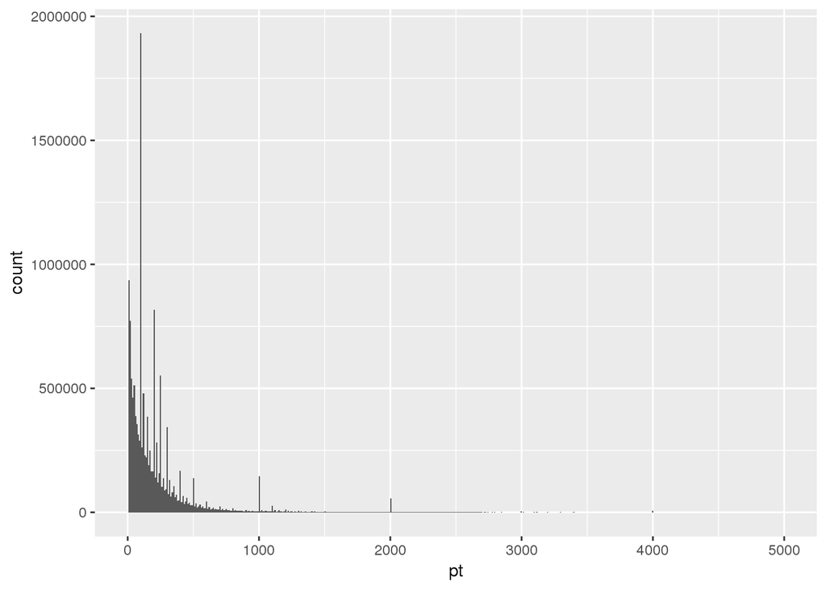

```r
scene_pt_fact%>%
  filter(txn_tp_1=="issuance")%>%
  ggplot(mapping = aes(x=pt))+
  geom_histogram(bins=500) + scale_x_continuous(limits = c(0, 5000))
```

```r
group_by(scene_pt_fact, txn_tp_2)%>%
  filter(txn_tp_1=="issuance")%>%
  summarise(count=n(), total_pts = sum(as.numeric(pt), na.rm=TRUE))%>%
  arrange(desc(count))
```

```
## # A tibble: 5 x 3
##      txn_tp_2    count  total_pts
##         <chr>    <int>      <dbl>
## 1     regular 14436312 2886735752
## 2 enrollbonus   572383  276113896
## 3  promobonus   280342  108207770
## 4  otherbonus       24          0
## 5 surveybonus        5       8000
```

```r
group_by(scene_pt_fact, txn_tp_3)%>%
  filter(txn_tp_1=="issuance")%>%
  summarise(count=n(), total_pts = sum(as.numeric(pt), na.rm=TRUE))%>%
  arrange(desc(count))
```

```
## # A tibble: 3 x 3
##   txn_tp_3   count  total_pts
##      <chr>   <int>      <dbl>
## 1  non_cin 7635816 1634723583
## 2      cin 5228210 1148638136
## 3  unknown 2425040  487703699
```

94% of issuances and 88% of points issued were associated with regular transactions. 50% of points issued happened outside of cineplex theaters.

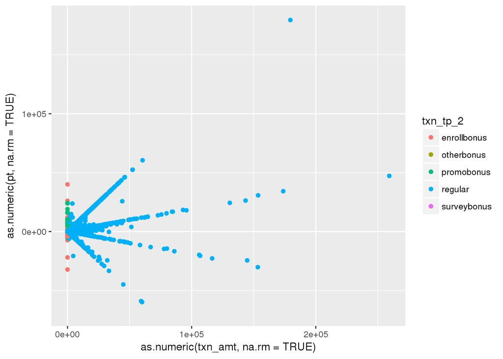

```r
scene_pt_fact %>%
  filter(txn_tp_1=="issuance")%>%
  ggplot(aes(x=as.numeric(txn_amt, na.rm=TRUE), y=as.numeric(pt, na.rm=TRUE), group=txn_tp_2, colour=txn_tp_2)) + geom_point()
```

While enrollment and promotional bonuses are typically not involving dollar transactions, regular points seems to follow a few specific earn rates, which likely represent earn rates at cineplex vs. non-cineplex locations. Note that sometimes, dollar spend triggers negative points, these could be redemptions at the same time of purchases, or potentially data base errors.

## Redemptions

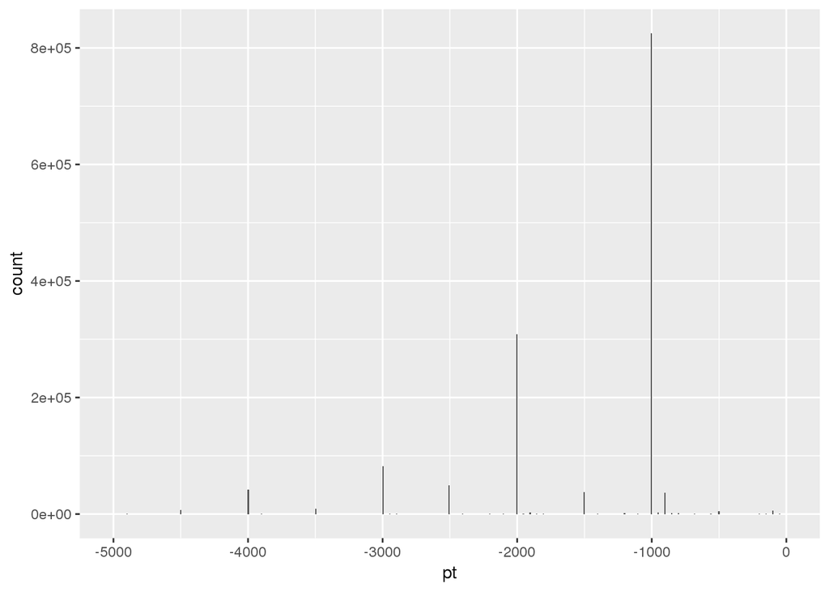

```r
scene_pt_fact%>%
  filter(txn_tp_1=="redemption")%>%
  ggplot(mapping = aes(x=pt))+
  geom_histogram(bins=500) + scale_x_continuous(limits = c(-5000, 0))
```

```r
group_by(scene_pt_fact, txn_tp_3)%>%
  filter(txn_tp_1=="redemption")%>%
  summarise(count=n(), total_pts = sum(as.numeric(pt), na.rm=TRUE))%>%
  arrange(desc(count))
```

```
## # A tibble: 2 x 3
##   txn_tp_3   count   total_pts
##      <chr>   <int>       <dbl>
## 1      cin 1468222 -2408839668
## 2  unknown   13260   -50226485
```

The number of points redeemed tends to be multipliers of 1000, which is worth a general admission ticket. 98% of points were redeemed at cineplex theaters.